# Лабораторная работа № 1

## Установка ОС Linux

**Студент:** Sackolassine  
**Группа:** НПИБД-02-25  
**Операционная система:** Fedora Sway 41  
**Виртуализация:** QEMU/KVM  
**Год:** 2026

# Слайд 2. Цель работы

- Установить Linux в виртуальной машине.
- Выполнить первоначальную настройку системы.
- Изучить команды диагностики Linux.
- Получить сведения о ядре, процессоре, памяти и файловых системах.

# Слайд 3. Используемые средства

- Хостовая ОС: Ubuntu Linux.
- Гостевая ОС: Fedora Sway 41.
- Виртуализация: QEMU/KVM.
- Установочный образ: `Fedora-Sway-Live-x86_64-41-1.4.iso`.
- Виртуальный диск: QCOW2.

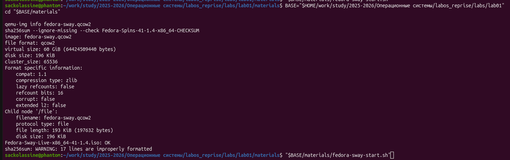

Подготовка виртуальной машины

# Слайд 4. Запуск виртуальной машины

Виртуальная машина запускается с помощью QEMU/KVM.

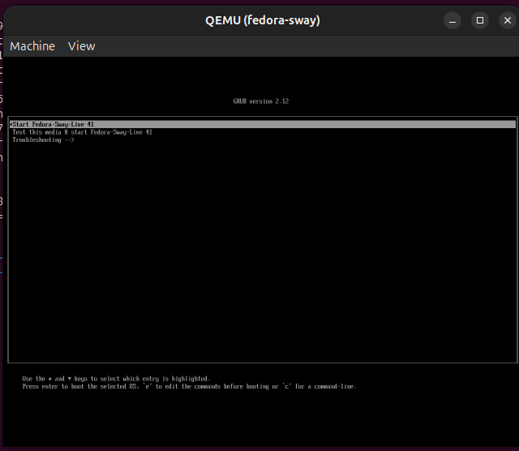

Запуск QEMU

# Слайд 5. Установка Fedora

- Запуск установочного ISO-образа.
- Открытие среды Fedora Live.
- Запуск установщика операционной системы.

[figure not shown]

Fedora Live

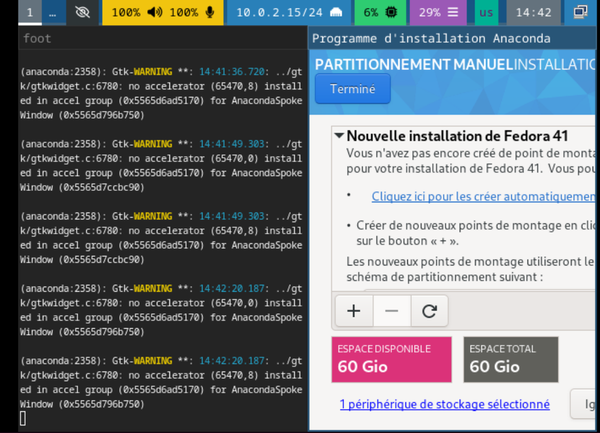

Установщик Fedora

# Слайд 6. Настройка установки

- Настройка клавиатуры.
- Выбор виртуального диска.
- Завершение установки.

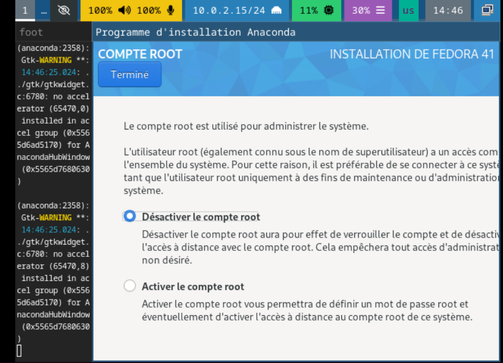

[figure not shown]

# Слайд 7. Первый запуск

После установки была выполнена попытка входа в систему. Возникшую проблему авторизации удалось диагностировать и восстановить доступ.

[figure not shown]

[figure not shown]

Восстановление доступа

# Слайд 8. Работа в терминале

После восстановления доступа был открыт терминал Fedora Sway.

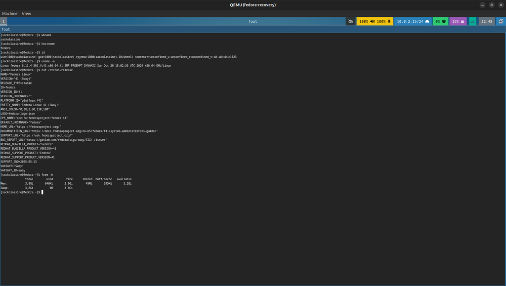

Терминал Fedora

# Слайд 9. Информация о системе

Основные команды диагностики:

```bash
uname -a
cat /etc/os-release
```

- `uname -a` — информация о ядре и архитектуре.
- `cat /etc/os-release` — сведения о дистрибутиве.

[figure not shown]

# Слайд 10. Ядро, процессор и память

```bash
sudo dmesg
sudo dmesg | grep -Ei 'Linux version|CPU0|MHz|Memory|hypervisor'
free -h
lscpu
```

Команды позволяют изучить сообщения ядра, сведения о процессоре и объём оперативной памяти.

[figure not shown]

[figure not shown]

# Слайд 11. Файловые системы

```bash
findmnt
lsblk -f
df -hT
```

- `findmnt` — точки монтирования.
- `lsblk -f` — диски, разделы и типы файловых систем.
- `df -hT` — использование места на файловых системах.

[figure not shown]

# Слайд 12. Основные выводы

- Подготовлена виртуальная среда QEMU/KVM.
- Установлена Fedora Sway 41.
- Восстановлен доступ к установленной системе.
- Изучены команды диагностики Linux.
- Подготовлены снимки экрана, документирующие этапы работы.

# Спасибо за внимание!